# Results across platforms

Selene Fregosi

28 May 2024

Created following https://taikisan21.github.io/PAMpal/banterGuide.html

## Setup

```r
library(banter)
library(rfPermute)
library(tidyverse)
```

```r
path_models <- file.path('T:/fregosi/cross_platform_banter_big_data/models')
```

## Load models and data

```r
# towed array model
modelFile <- file.path(path_models,  'bantMDL_HICEAS2017-CH5_Filtered_577_2024-05-20.rdata')

load(modelFile)
bant.mdl_ta <- bant.mdl

bant.rf_ta <- getBanterModel(bant.mdl_ta)
bantData.df_ta <- getBanterModelData(bant.mdl_ta)

# longline model
modelFile <- file.path(path_models, 'bantMDL_LLHARP_2024-05-27_ss15_nt10k.rda')

load(modelFile)
bant.mdl_ll <- bant.mdl

bant.rf_ll <- getBanterModel(bant.mdl_ll)
bantData.df_ll <- getBanterModelData(bant.mdl_ll)

# glider model
modelFile <- file.path(path_models, 'bantMDL_glider_2024-05-28_ss5_nt12k.rda')

load(modelFile)
bant.mdl_gl <- bant.mdl

bant.rf_gl <- getBanterModel(bant.mdl_gl)
bantData.df_gl <- getBanterModelData(bant.mdl_gl)
```

```r
# towed array data
trainingFile <- file.path('R:/McCullough/PAMpal/Banter_TowedArray_Data',
                          'banterAllsmall_HICEAS2017-CH5_Filtered-577.rdata')

load(trainingFile) # called banterAllsmall

# longline data
trainingFile <- file.path('T:/fregosi/cross_platform_banter_big_data',
                          'banterDetsTrain_LLHARP_2024-05-27.rda')
load(trainingFile) # called banterDetsTrain
banterDetsTrain_ll <- banterDetsTrain

# glider data
trainingFile <- file.path('T:/fregosi/cross_platform_banter_big_data',
                          'banterDetsTrain_glider_2024-05-28.rda')
load(trainingFile) # called banterDetsTrain
banterDetsTrain_gl <- banterDetsTrain
```

## Towed array

### Model results

#### Model Information

**Detector Names & Sample Sizes**  
Show the Detector Names and Sample Sizes

```r
# Get detector names for your _BANTER_ Model
getDetectorNames(bant.mdl_ta)
```

```
[1] "Cepstrum_Detector"         "Click_Detector_1"
[3] "Click_Detector_2"          "Click_Detector_3"
[5] "Click_Detector_4"          "Click_Detector_5"
[7] "Whistle_and_Moan_Detector"
```

```r
# Get Sample sizes
getSampSize(bant.mdl_ta)
```

```
 X33 X577
  15   15
```

**Number of Calls & Events, Proportion of Calls**  
Number of calls (`numCalls()`), proportion of calls (`propCalls()`) and number of events (`numEvents()`) in your *BANTER* detector models (or specify by event/species)

```r
# number of calls in detector model
numCalls(bant.mdl_ta)
```

```
  species num.Cepstrum_Detector num.Click_Detector_1 num.Click_Detector_2
1     X33                  2436                97576                61833
2    X577                 15491               185434               109738
  num.Click_Detector_3 num.Click_Detector_4 num.Click_Detector_5
1               115709                   25                 5061
2               150932                  311                 4144
  num.Whistle_and_Moan_Detector
1                         53011
2                         12577
```

```r
# number of calls by species (can also do by event)
numCalls(bant.mdl_ta, "species")
```

```
  species num.Cepstrum_Detector num.Click_Detector_1 num.Click_Detector_2
1     X33                  2436                97576                61833
2    X577                 15491               185434               109738
  num.Click_Detector_3 num.Click_Detector_4 num.Click_Detector_5
1               115709                   25                 5061
2               150932                  311                 4144
  num.Whistle_and_Moan_Detector
1                         53011
2                         12577
```

```r
# proportion of calls in detector model
propCalls(bant.mdl_ta)
```

```
  species prop.Cepstrum_Detector prop.Click_Detector_1 prop.Click_Detector_2
1     X33            0.007257538             0.2907067             0.1842181
2    X577            0.032365495             0.3874290             0.2292767
  prop.Click_Detector_3 prop.Click_Detector_4 prop.Click_Detector_5
1             0.3447301          7.448213e-05           0.015078162
2             0.3153437          6.497753e-04           0.008658099
  prop.Whistle_and_Moan_Detector
1                     0.15793488
2                     0.02627725
```

```r
# proportion of calls by event (can also do by species)
#propCalls(bant.mdl_ta, "event")
#[this is commented out as printout is long]

# number of events, with default for Event Model
numEvents(bant.mdl_ta)
```

[output not shown]

```r
# number of events for a specific detector
numEvents(bant.mdl_ta, "Whistle_and_Moan_Detector")
```

```
  species num.events
1     X33         20
2    X577         94
```

#### Random Forest Summaries

The following functions are available in the `rfPermute` package and take a `randomForest` or `rfPermute` model object. Recall from above that the actual `randomForest` object can be extracted from the *BANTER* model with the `getBanterModel()` function.

**Confusion Matrix**  
The Confusion Matrix is the most commonly used output for a Random Forest model, and is provided by `summary()`. The output includes the percent correctly classified for each species, the lower and upper confidence levels, and the priors (expected classification rate).

By default, `summary()` reports the 95% confidence levels of the percent correctly classified. By using the `confusionMatrix()` function, we can specify a different confidence level if desired. However, unlike `summary()`, `confusionMatrix()` takes a `randomForest` object like the one we extracted above.

```r
# Confusion Matrix
confusionMatrix(bant.rf_ta, conf.level = 0.75)
```

[output not shown]

The `confusionMatrix()` function also has a `threshold` argument that provides the binomial probability that the true classification probability (given infinite data) is greater than or equal to this value. For example, if we want to know what the probability is that the true classification probability for each species is >= 0.80, we set `threshold = 0.8`:

```r
# Confusion Matrix with medium threshold
confusionMatrix(bant.rf_ta, threshold = 0.8)
```

```
        X33 X577 pct.correct LCI_0.95  UCI_0.95     Pr.gt_0.8
X33      20    0   100.00000 83.15665 100.00000 1.220165e-119
X577      4  204    98.07692 95.14962  99.47360  9.999580e-01
Overall  NA   NA    98.24561 95.56924  99.51997  1.000000e+00
```

And alternative view of the confusion matrix comes in the form of a heat map.

```r
# Plot Confusion Matrix Heatmap
plotConfMat(bant.rf_ta, title="Confusion Matrix HeatMap")
```

[output not shown]

We can also examine confusion matrices for individual detectors, such as the whistle detector (“Whistle_and_Moan_Detector”):

```r
wmd.rf <- getBanterModel(bant.mdl_ta, "Whistle_and_Moan_Detector")
confusionMatrix(wmd.rf)
plotConfMat(wmd.rf)
```

[output not shown]

**Model Percent Correct**  
This function operates on a *BANTER* model object and provides a summary data frame with the percent of each species correctly classified for each detector model and the event model. It is a summary of the diagonal values from the confusion matrices for all models.

```r
modelPctCorrect(bant.mdl_ta)
```

```
# A tibble: 3 × 9
  species Cepstrum_Detector Click_Detector_1 Click_Detector_2 Click_Detector_3
  <fct>               <dbl>            <dbl>            <dbl>            <dbl>
1 X33                  73.8             77.8             73.4             83.6
2 X577                 61.3             70.0             67.0             80.3
3 Overall              63.0             72.7             69.3             81.7
# ℹ 4 more variables: Click_Detector_4 <dbl>, Click_Detector_5 <dbl>,
#   Whistle_and_Moan_Detector <dbl>, event <dbl>
```

**Plot Votes**  
The strength of a classification model depends on the number of trees that ‘voted’ for the correct species. We can look at the votes from each of these 5,000 trees for an event to see how many of them were correct. This plot shows these votes where each vertical slice is an event, and the percentage of votes for each species is represented by their color. If all events for a species were to be correctly classified by all of the trees (votes) in the forest, then the plot for that species would be solid in the color that represents that species.

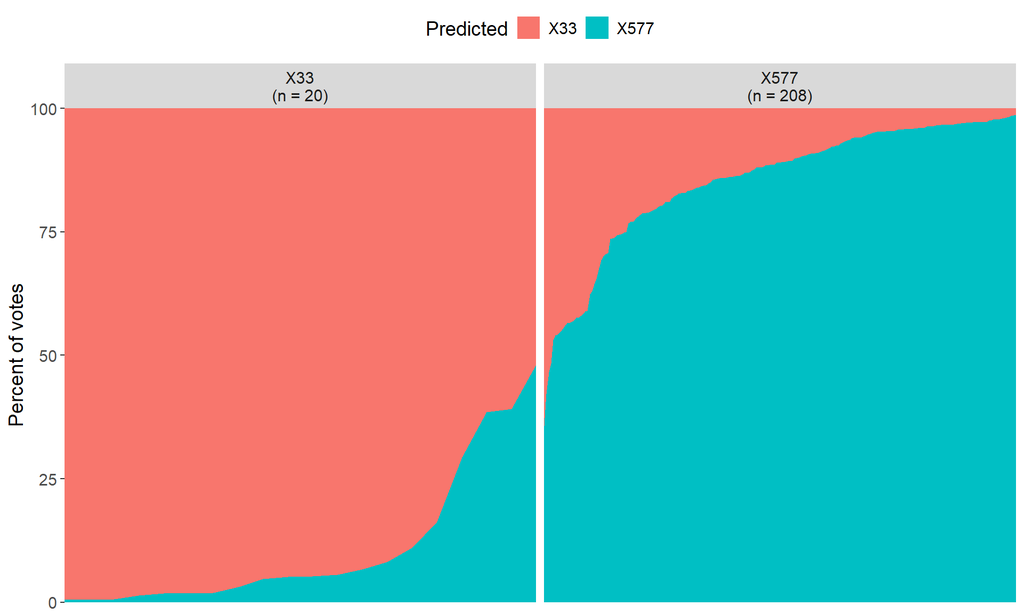

```r
# Plot Vote distribution
plotVotes(bant.rf_ta)
```

**Percent Correct**  
Another way to visualize this distribution is to evaluate the percent of events correctly classified for a given threshold (specified percent of trees in the forest voting for that species).

```r
# Percent Correct for a series of thresholds
pctCorrect(bant.rf_ta, pct = c(0.8, 0.6, 0.5))
```

```
    class pct.correct_0.8 pct.correct_0.6 pct.correct_0.5
1     X33        80.00000        95.00000       100.00000
2    X577        75.96154        90.38462        98.07692
3 Overall        76.31579        90.78947        98.24561
```

**Plot Predicted Probabilities**  
The full distribution of assignment probabilities to the predicted species class can be visualized with the `plotPredictedProbs()` function in `rfPermute`. Ideally, all events would be classified to the correct species (identified by the color), and would be strongly classified to the correct species (higher probablity of assignment). This plot can be used to understand the distribution of these classifications, and how strong the misclassifications were, by species.

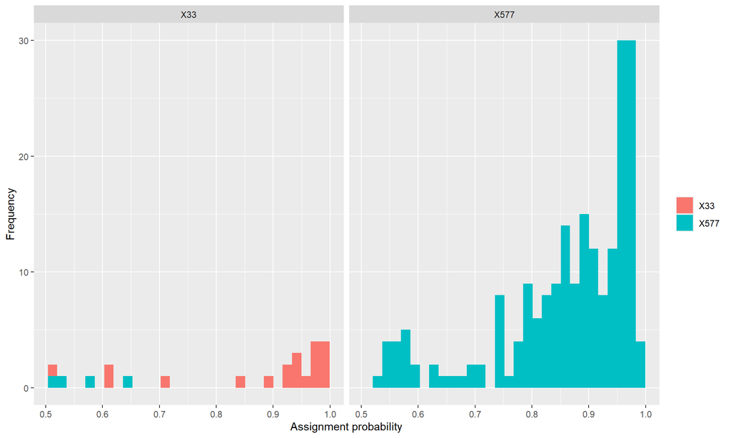

```r
plotPredictedProbs(bant.rf_ta, bins = 30, plot = TRUE)
```

**Proximity Plot**  
The proximity plot provides a visualization of the distribution of events within the tree space. It shows the relative distance of events based on their average distance in nodes in the trees across the forest. For each event in the plot, the color of the central dot represents the true species identity, and the color of the circle represents the *BANTER* classification. Ideally, these would form rather distinct clusters, one for each species. The wider the spread of the events in this feature space, the more variation found in these predictors. Some species differentiation may be predicted by other predictors and may not be clear based on this pair of dimensions (those may be differentiated with different predictors).

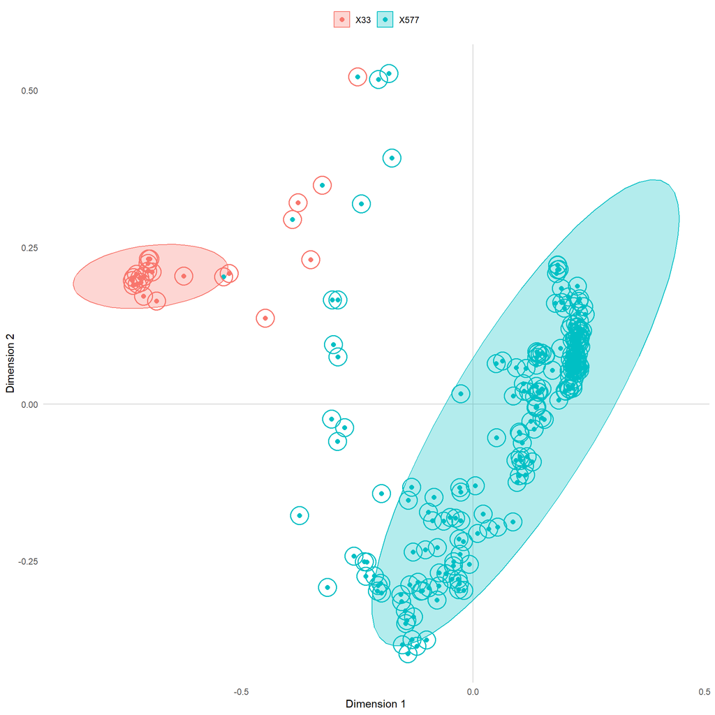

```r
# Proximity Plot
plotProximity(bant.rf_ta)
```

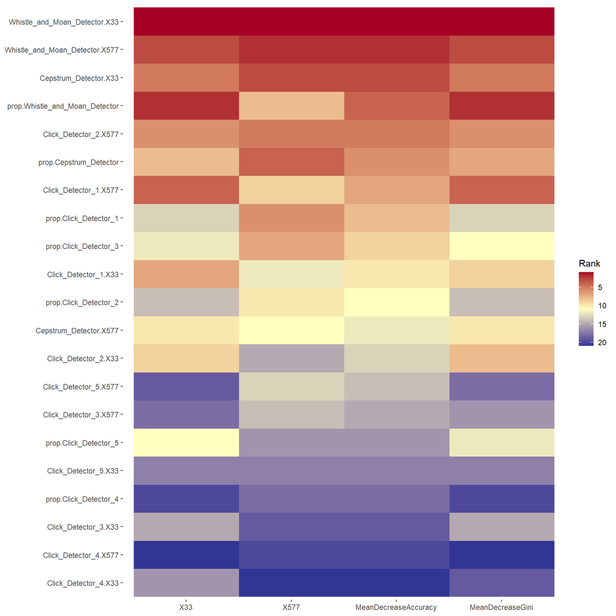

```r
# Importance Heat Map
plotImportance(bant.rf_ta, plot.type = "heatmap")
```

#### Mis-Classified Events

By segregating the misclassified events, you can dive deeper into these data to understand why the model failed. Perhaps they were incorrectly classified in the first place (inaccurate training data) or the misclassification could be due to natural variability in the call characteristics. There are any number of possibilities, and by diving into the misclassifications, you can learn a lot about your data and your model. We do not recommend eliminating misclassifications simply because they are misclassifications. The point is to learn more about your data, not to cherry pick your data to get the best performing model.

**Case Predictions** If it is important to identify only strong classification results, they can be identified and filtered using the `casePredictions()` function in `rfPermute`.

```r
casePredict <- casePredictions(bant.rf_ta)
head(casePredict)
```

```
   id original predicted is.correct        X33      X577
1  L2     X577      X577       TRUE 0.13075427 0.8692457
2  L8     X577      X577       TRUE 0.21223565 0.7877644
3  L9     X577      X577       TRUE 0.16455422 0.8354458
4 L11     X577      X577       TRUE 0.16743985 0.8325601
5 L12     X577      X577       TRUE 0.19600648 0.8039935
6 L13     X577      X577       TRUE 0.04182427 0.9581757
```

This function returns a data frame with the original and predicted species for each event along with if the event was correctly classified and the assignment probabilities to each species.  
To identify misclassified events, we just filter this data frame and grab the original event id.

```r
misclass <- casePredict %>%
  filter(!is.correct) %>%
  select(id)

casePredict[casePredict$id %in% misclass$id,]
```

```
      id original predicted is.correct       X33      X577
69  L264     X577       X33      FALSE 0.5163307 0.4836693
125  S79     X577       X33      FALSE 0.5336487 0.4663513
126  S80     X577       X33      FALSE 0.5785329 0.4214671
215 S311     X577       X33      FALSE 0.6435355 0.3564645
```

We can then look closer at these events to learn more about them.

#### Variable Importance

One of the powerful features of Random Forest is the ability to assess and rank which predictors are important to the classification model. These values are based on measures of how much worse the classifier performs when the predictor variables are randomly permuted. The `importance()` function in the `randomForest` package extracts these values from a `randomForest` object.

To see the actual distribution of these values in each species, we can first identify the most important predictors (highest importance scores).

```r
# Get importance scores and convert to a data frame
bant.imp <- data.frame(importance(bant.rf_ta))
head(bant.imp)
```

```
                             X33      X577 MeanDecreaseAccuracy
prop.Cepstrum_Detector 25.159464 19.012717            21.946945
prop.Click_Detector_1  16.391521 15.806502            17.016303
prop.Click_Detector_2  12.828001 12.404165            13.467302
prop.Click_Detector_3  17.642473 14.599814            16.284990
prop.Click_Detector_4   1.395107  1.262879             1.394947
prop.Click_Detector_5  17.751268  3.108171             5.669217
                       MeanDecreaseGini
prop.Cepstrum_Detector       0.67629307
prop.Click_Detector_1        0.24658100
prop.Click_Detector_2        0.22202255
prop.Click_Detector_3        0.38730153
prop.Click_Detector_4        0.05240242
prop.Click_Detector_5        0.33993791
```

```r
# Select top 4 important event stage predictors
bant.4imp <- bant.imp[order(bant.imp$MeanDecreaseAccuracy, decreasing = TRUE), ][1:4, ]
bant.4imp
```

```
                                    X33     X577 MeanDecreaseAccuracy
Whistle_and_Moan_Detector.X33  80.69049 34.78348             63.13377
Whistle_and_Moan_Detector.X577 47.38594 24.98018             31.86174
Cepstrum_Detector.X33          30.96674 23.65130             27.46880
prop.Whistle_and_Moan_Detector 56.01503 13.56358             24.24584
                               MeanDecreaseGini
Whistle_and_Moan_Detector.X33         4.0648411
Whistle_and_Moan_Detector.X577        1.5550690
Cepstrum_Detector.X33                 0.7658638
prop.Whistle_and_Moan_Detector        2.2283533
```

```r
# plotImpPreds(bant.rf_ta, bantData.df_ta, "species", max.vars = 4)
```

### Predictions

```r
# Check for click_detector_0 in training dataset
banterAllsmall$detectors$Click_Detector_0 <- NULL

# predict on towed array data with towed array model
score_ta_ta <- banter::predict(bant.mdl_ta, banterAllsmall)
save(score_ta_ta, file = file.path(path_models, 'predictions_TAbyTA.rda'))

score_ta_ta$validation.matrix
```

```
        predicted
original X33 X577
    X33   20    0
    X577   3  205
```

```r
# predict on towed array data with longline model
score_ta_ll <- banter::predict(bant.mdl_ll, banterAllsmall)
save(score_ta_ll, file = file.path(path_models, 'predictions_TAbyLL.rda'))

score_ta_ll$validation.matrix
```

```
        predicted
original  Pc  UO
    X33   19   1
    X577  32 176
```

```r
# predict on towed array data with glider model
score_ta_gl <- banter::predict(bant.mdl_gl, banterAllsmall)
save(score_ta_gl, file = file.path(path_models, 'predictions_TAbyGL.rda'))

score_ta_gl$validation.matrix
```

```
        predicted
original  Pc  UO
    X33   19   1
    X577  50 158
```

## Longline

### Model results

#### Model Information

**Detector Names & Sample Sizes**  
Show the Detector Names and Sample Sizes

```r
# Get detector names for your _BANTER_ Model
getDetectorNames(bant.mdl_ll)
```

```
[1] "Cepstrum_Detector"         "Click_Detector_1"
[3] "Click_Detector_2"          "Click_Detector_3"
[5] "Click_Detector_4"          "Click_Detector_5"
[7] "Whistle_and_Moan_Detector"
```

```r
# Get Sample sizes
getSampSize(bant.mdl_ll)
```

```
Pc UO
15 15
```

**Number of Calls & Events, Proportion of Calls**  
Number of calls (`numCalls()`), proportion of calls (`propCalls()`) and number of events (`numEvents()`) in your *BANTER* detector models (or specify by event/species)

```r
# number of calls in detector model
numCalls(bant.mdl_ll)
```

```
  species num.Cepstrum_Detector num.Click_Detector_1 num.Click_Detector_2
1      Pc                 15445                23505                31377
2      UO                 25957                54122               170016
  num.Click_Detector_3 num.Click_Detector_4 num.Click_Detector_5
1                 2601                   29                  360
2               194065                  936                 3650
  num.Whistle_and_Moan_Detector
1                         64925
2                         26647
```

```r
# number of calls by species (can also do by event)
numCalls(bant.mdl_ll, "species")
```

```
  species num.Cepstrum_Detector num.Click_Detector_1 num.Click_Detector_2
1      Pc                 15445                23505                31377
2      UO                 25957                54122               170016
  num.Click_Detector_3 num.Click_Detector_4 num.Click_Detector_5
1                 2601                   29                  360
2               194065                  936                 3650
  num.Whistle_and_Moan_Detector
1                         64925
2                         26647
```

```r
# proportion of calls in detector model
propCalls(bant.mdl_ll)
```

```
  species prop.Cepstrum_Detector prop.Click_Detector_1 prop.Click_Detector_2
1      Pc             0.11172437             0.1700279             0.2269715
2      UO             0.05460114             0.1138469             0.3576325
  prop.Click_Detector_3 prop.Click_Detector_4 prop.Click_Detector_5
1            0.01881483          0.0002097771           0.002604129
2            0.40822015          0.0019688973           0.007677858
  prop.Whistle_and_Moan_Detector
1                     0.46964743
2                     0.05605257
```

```r
# proportion of calls by event (can also do by species)
#propCalls(bant.mdl, "event")
#[this is commented out as printout is long]

# number of events, with default for Event Model
numEvents(bant.mdl_ll)
```

```
  species num.events
1      Pc         48
2      UO        395
```

```r
# number of events for a specific detector
numEvents(bant.mdl_ll, "Whistle_and_Moan_Detector")
```

```
  species num.events
1      Pc         48
2      UO        253
```

#### Random Forest Summaries

The following functions are available in the `rfPermute` package and take a `randomForest` or `rfPermute` model object. Recall from above that the actual `randomForest` object can be extracted from the *BANTER* model with the `getBanterModel()` function.

**Confusion Matrix**  
The Confusion Matrix is the most commonly used output for a Random Forest model, and is provided by `summary()`. The output includes the percent correctly classified for each species, the lower and upper confidence levels, and the priors (expected classification rate).

By default, `summary()` reports the 95% confidence levels of the percent correctly classified. By using the `confusionMatrix()` function, we can specify a different confidence level if desired. However, unlike `summary()`, `confusionMatrix()` takes a `randomForest` object like the one we extracted above.

```r
# Confusion Matrix
confusionMatrix(bant.rf_ll, conf.level = 0.75)
```

[output not shown]

The `confusionMatrix()` function also has a `threshold` argument that provides the binomial probability that the true classification probability (given infinite data) is greater than or equal to this value. For example, if we want to know what the probability is that the true classification probability for each species is >= 0.80, we set `threshold = 0.8`:

```r
# Confusion Matrix with medium threshold
confusionMatrix(bant.rf_ll, threshold = 0.8)
```

```
        Pc  UO pct.correct LCI_0.95 UCI_0.95     Pr.gt_0.8
Pc      47   1    97.91667 88.93038 99.94727 3.431938e-218
UO       6 389    98.48101 96.72327 99.44057  9.999949e-01
Overall NA  NA    98.41986 96.77154 99.36240  1.000000e+00
```

And alternative view of the confusion matrix comes in the form of a heat map.

```r
# Plot Confusion Matrix Heatmap
plotConfMat(bant.rf_ll, title="Confusion Matrix HeatMap")
```

[output not shown]

We can also examine confusion matrices for individual detectors, such as the whistle detector (“Whistle_and_Moan_Detector”):

```r
wmd.rf <- getBanterModel(bant.mdl_ll, "Whistle_and_Moan_Detector")
confusionMatrix(wmd.rf)
plotConfMat(wmd.rf)
```

[output not shown]

**Model Percent Correct**  
This function operates on a *BANTER* model object and provides a summary data frame with the percent of each species correctly classified for each detector model and the event model. It is a summary of the diagonal values from the confusion matrices for all models.

```r
modelPctCorrect(bant.mdl_ll)
```

```
# A tibble: 3 × 9
  species Cepstrum_Detector Click_Detector_1 Click_Detector_2 Click_Detector_3
  <fct>               <dbl>            <dbl>            <dbl>            <dbl>
1 Pc                   62.8             71.6             80.0             76.2
2 UO                   78.9             68.7             72.2             77.3
3 Overall              72.9             69.6             73.4             77.3
# ℹ 4 more variables: Click_Detector_4 <dbl>, Click_Detector_5 <dbl>,
#   Whistle_and_Moan_Detector <dbl>, event <dbl>
```

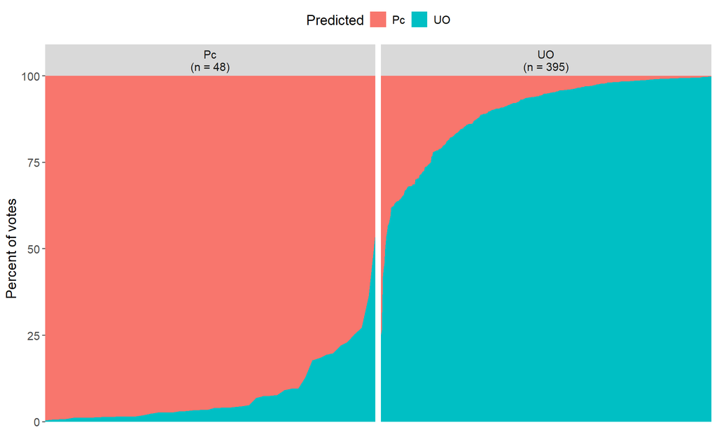

```r
# Plot Vote distribution
plotVotes(bant.rf_ll)
```

**Percent Correct**  
Another way to visualize this distribution is to evaluate the percent of events correctly classified for a given threshold (specified percent of trees in the forest voting for that species).

```r
# Percent Correct for a series of thresholds
pctCorrect(bant.rf_ll, pct = c(0.8, 0.6, 0.5))
```

```
    class pct.correct_0.8 pct.correct_0.6 pct.correct_0.5
1      Pc        87.50000        97.91667        97.91667
2      UO        80.75949        96.96203        98.48101
3 Overall        81.48984        97.06546        98.41986
```

**Plot Predicted Probabilities**  
The full distribution of assignment probabilities to the predicted species class can be visualized with the `plotPredictedProbs()` function in `rfPermute`. Ideally, all events would be classified to the correct species (identified by the color), and would be strongly classified to the correct species (higher probablity of assignment). This plot can be used to understand the distribution of these classifications, and how strong the misclassifications were, by species.

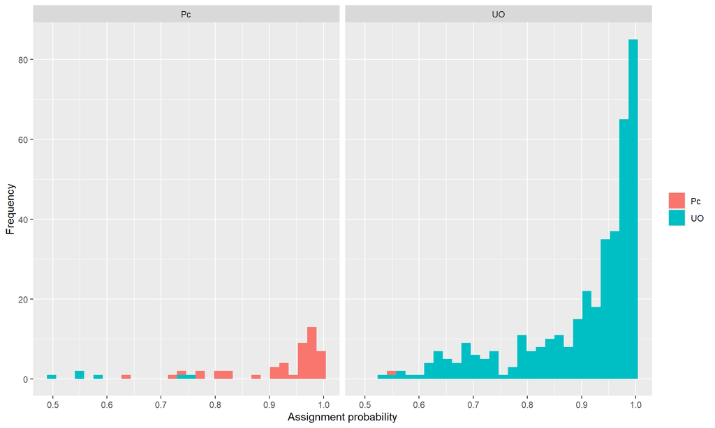

```r
plotPredictedProbs(bant.rf_ll, bins = 30, plot = TRUE)
```

**Proximity Plot**  
The proximity plot provides a visualization of the distribution of events within the tree space. It shows the relative distance of events based on their average distance in nodes in the trees across the forest. For each event in the plot, the color of the central dot represents the true species identity, and the color of the circle represents the *BANTER* classification. Ideally, these would form rather distinct clusters, one for each species. The wider the spread of the events in this feature space, the more variation found in these predictors. Some species differentiation may be predicted by other predictors and may not be clear based on this pair of dimensions (those may be differentiated with different predictors).

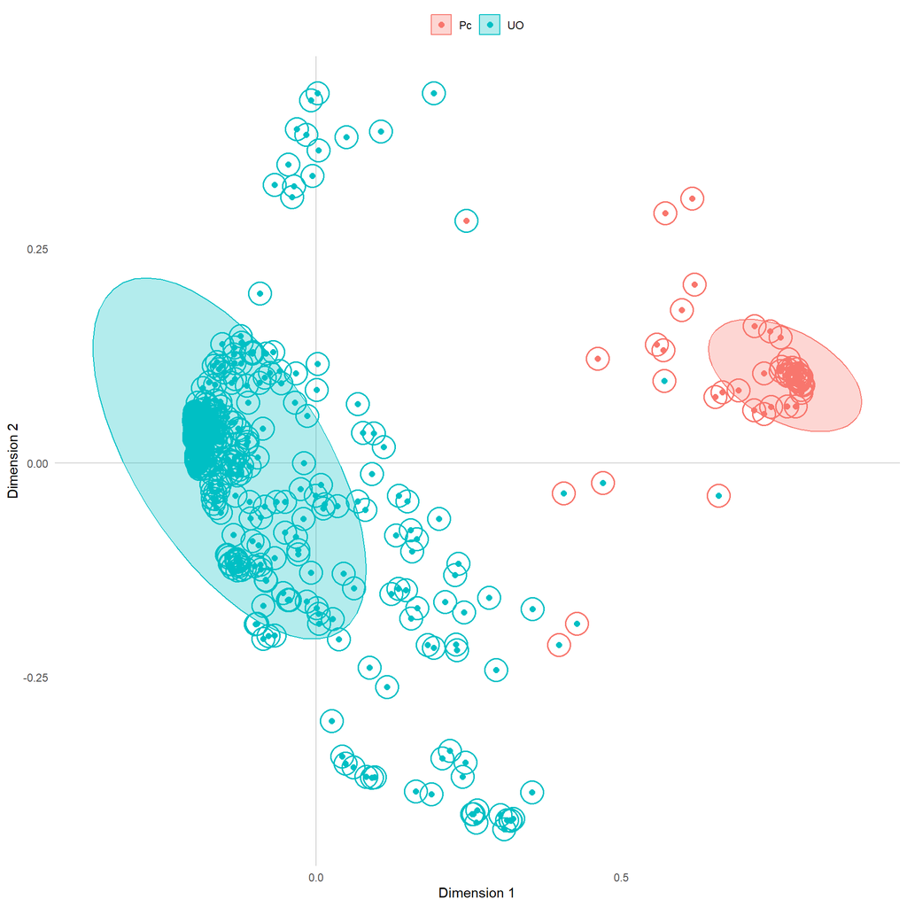

```r
# Proximity Plot
plotProximity(bant.rf_ll)
```

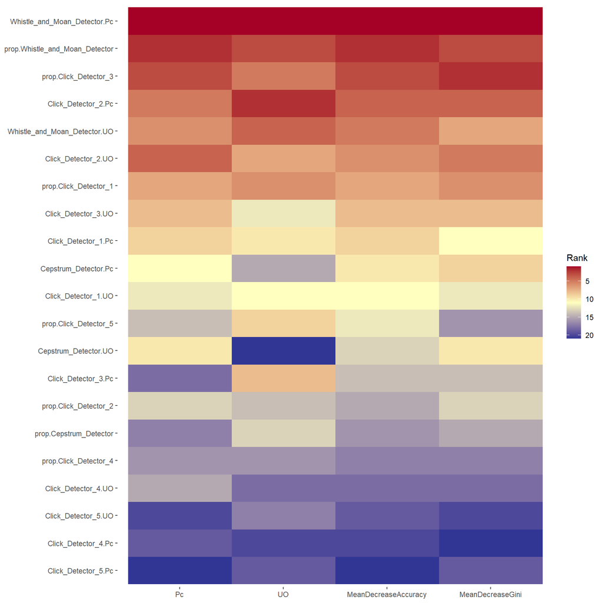

```r
# Importance Heat Map
plotImportance(bant.rf_ll, plot.type = "heatmap")
```

#### Mis-Classified Events

By segregating the misclassified events, you can dive deeper into these data to understand why the model failed. Perhaps they were incorrectly classified in the first place (inaccurate training data) or the misclassification could be due to natural variability in the call characteristics. There are any number of possibilities, and by diving into the misclassifications, you can learn a lot about your data and your model. We do not recommend eliminating misclassifications simply because they are misclassifications. The point is to learn more about your data, not to cherry pick your data to get the best performing model.

**Case Predictions** If it is important to identify only strong classification results, they can be identified and filtered using the `casePredictions()` function in `rfPermute`.

```r
casePredict <- casePredictions(bant.rf_ll)
head(casePredict)
```

```
           id original predicted is.correct        Pc         UO
1 LL003FR07_1       UO        UO       TRUE 0.3782238 0.62177621
2 LL003FR07_6       UO        UO       TRUE 0.4636685 0.53633146
3 LL003FR07_7       UO        UO       TRUE 0.0719260 0.92807400
4 LL003FR10_4       UO        UO       TRUE 0.2949715 0.70502851
5 LL003FR10_5       Pc        Pc       TRUE 0.9729253 0.02707475
6 LL003FR10_6       UO        UO       TRUE 0.3623987 0.63760133
```

This function returns a data frame with the original and predicted species for each event along with if the event was correctly classified and the assignment probabilities to each species.  
To identify misclassified events, we just filter this data frame and grab the original event id.

```r
misclass <- casePredict %>%
  filter(!is.correct) %>%
  select(id)

casePredict[casePredict$id %in% misclass$id,]
```

```
                   id original predicted is.correct        Pc        UO
34              39_06       UO        Pc      FALSE 0.5423887 0.4576113
39              39_12       UO        Pc      FALSE 0.5577183 0.4422817
60               43_5       UO        Pc      FALSE 0.5007791 0.4992209
96               50_4       UO        Pc      FALSE 0.7355329 0.2644671
261 LL063_FR63_DL73_4       UO        Pc      FALSE 0.5793692 0.4206308
312 LL065_FR51_DL64_2       Pc        UO      FALSE 0.4567336 0.5432664
438 LL070_FR64_DL88_1       UO        Pc      FALSE 0.7477102 0.2522898
```

We can then look closer at these events to learn more about them.

#### Variable Importance

One of the powerful features of Random Forest is the ability to assess and rank which predictors are important to the classification model. These values are based on measures of how much worse the classifier performs when the predictor variables are randomly permuted. The `importance()` function in the `randomForest` package extracts these values from a `randomForest` object.

To see the actual distribution of these values in each species, we can first identify the most important predictors (highest importance scores).

```r
# Get importance scores and convert to a data frame
bant.imp <- data.frame(importance(bant.rf_ll))
head(bant.imp)
```

```
                              Pc        UO MeanDecreaseAccuracy
prop.Cepstrum_Detector  9.712457  6.457343             9.084260
prop.Click_Detector_1  32.727299 19.248423            32.877680
prop.Click_Detector_2  14.307857  6.356080             9.694714
prop.Click_Detector_3  48.188910 21.095363            42.917337
prop.Click_Detector_4  10.359501  2.514629             5.922601
prop.Click_Detector_5  14.058307 10.583638            13.259391
                       MeanDecreaseGini
prop.Cepstrum_Detector       0.12500803
prop.Click_Detector_1        0.94644034
prop.Click_Detector_2        0.18110176
prop.Click_Detector_3        1.79958817
prop.Click_Detector_4        0.05761714
prop.Click_Detector_5        0.10285465
```

```r
# Select top 4 important event stage predictors
bant.4imp <- bant.imp[order(bant.imp$MeanDecreaseAccuracy, decreasing = TRUE), ][1:4, ]
bant.4imp
```

```
                                     Pc       UO MeanDecreaseAccuracy
Whistle_and_Moan_Detector.Pc   71.18836 63.52901             71.82574
prop.Whistle_and_Moan_Detector 48.31579 28.39724             44.83799
prop.Click_Detector_3          48.18891 21.09536             42.91734
Click_Detector_2.Pc            41.18773 30.02047             41.24103
                               MeanDecreaseGini
Whistle_and_Moan_Detector.Pc           3.505250
prop.Whistle_and_Moan_Detector         1.772904
prop.Click_Detector_3                  1.799588
Click_Detector_2.Pc                    1.711467
```

```r
# plotImpPreds(bant.rf_ll, bantData.df_ll, "species", max.vars = 4)
```

### Predictions

```r
# have to change the species names
uSp <- unique(banterDetsTrain_ll$events$species)
uSp <- uSp[-which(uSp == 'UO' | uSp == 'Pc')]

for (u in seq_along(uSp)){
  uSpIdx <- which(banterDetsTrain_ll$events$species == uSp[u])
  banterDetsTrain_ll$events$species[uSpIdx] <- 'UO'
}

# unique(banterDetsTrain$events$species)

# Check for click_detector_0 in training dataset
banterDetsTrain_ll$detectors$Click_Detector_0 <- NULL

# predict on longline data with longline model
score_ll_ll <- banter::predict(bant.mdl_ll, banterDetsTrain_ll)
save(score_ll_ll, file = file.path(path_models, 'predictions_LLbyLL.rda'))

score_ll_ll$validation.matrix
```

```
        predicted
original  Pc  UO
      Pc  48   0
      UO   5 390
```

```r
# predict on longline data with towed array model
score_ll_ta <- banter::predict(bant.mdl_ta, banterDetsTrain_ll)
save(score_ll_ta, file = file.path(path_models, 'predictions_LLbyTA.rda'))

score_ll_ta$validation.matrix
```

```
        predicted
original X33 X577
      Pc  23   25
      UO   0  395
```

```r
# predict on longline data with glider model
score_ll_gl <- banter::predict(bant.mdl_gl, banterDetsTrain_ll)
save(score_ll_gl, file = file.path(path_models, 'predictions_LLbyGL.rda'))

score_ll_gl$validation.matrix
```

```
        predicted
original  Pc  UO
      Pc  48   0
      UO  23 372
```

## Glider

### Model results

#### Model Information

**Detector Names & Sample Sizes**  
Show the Detector Names and Sample Sizes

```r
# Get detector names for your _BANTER_ Model
getDetectorNames(bant.mdl_gl)
```

```
[1] "Cepstrum_Detector"         "Click_Detector_1"
[3] "Click_Detector_2"          "Click_Detector_3"
[5] "Click_Detector_5"          "Whistle_and_Moan_Detector"
```

```r
# Get Sample sizes
getSampSize(bant.mdl_gl)
```

```
Pc UO
 5  5
```

**Number of Calls & Events, Proportion of Calls**  
Number of calls (`numCalls()`), proportion of calls (`propCalls()`) and number of events (`numEvents()`) in your *BANTER* detector models (or specify by event/species)

```r
# number of calls in detector model
numCalls(bant.mdl_gl)
```

```
  species num.Cepstrum_Detector num.Click_Detector_1 num.Click_Detector_2
1      Pc                  7061                 5199                 2132
2      UO                 28397                 4973                53509
  num.Click_Detector_3 num.Click_Detector_5 num.Whistle_and_Moan_Detector
1                  395                   10                         10238
2               159882                 1121                         13665
```

```r
# number of calls by species (can also do by event)
numCalls(bant.mdl_gl, "species")
```

```
  species num.Cepstrum_Detector num.Click_Detector_1 num.Click_Detector_2
1      Pc                  7061                 5199                 2132
2      UO                 28397                 4973                53509
  num.Click_Detector_3 num.Click_Detector_5 num.Whistle_and_Moan_Detector
1                  395                   10                         10238
2               159882                 1121                         13665
```

```r
# proportion of calls in detector model
propCalls(bant.mdl_gl)
```

```
  species prop.Cepstrum_Detector prop.Click_Detector_1 prop.Click_Detector_2
1      Pc              0.2820451            0.20766926            0.08516077
2      UO              0.1085732            0.01901379            0.20458656
  prop.Click_Detector_3 prop.Click_Detector_5 prop.Whistle_and_Moan_Detector
1            0.01577791          0.0003994408                     0.40894747
2            0.61129357          0.0042860365                     0.05224682
```

```r
# proportion of calls by event (can also do by species)
#propCalls(bant.mdl, "event")
#[this is commented out as printout is long]

# number of events, with default for Event Model
numEvents(bant.mdl_gl)
```

```
  species num.events
1      Pc         11
2      UO        129
```

```r
# number of events for a specific detector
numEvents(bant.mdl_gl, "Whistle_and_Moan_Detector")
```

```
  species num.events
1      Pc         11
2      UO        111
```

#### Random Forest Summaries

The following functions are available in the `rfPermute` package and take a `randomForest` or `rfPermute` model object. Recall from above that the actual `randomForest` object can be extracted from the *BANTER* model with the `getBanterModel()` function.

**Confusion Matrix**  
The Confusion Matrix is the most commonly used output for a Random Forest model, and is provided by `summary()`. The output includes the percent correctly classified for each species, the lower and upper confidence levels, and the priors (expected classification rate).

By default, `summary()` reports the 95% confidence levels of the percent correctly classified. By using the `confusionMatrix()` function, we can specify a different confidence level if desired. However, unlike `summary()`, `confusionMatrix()` takes a `randomForest` object like the one we extracted above.

```r
# Confusion Matrix
confusionMatrix(bant.rf_gl, conf.level = 0.75)
```

[output not shown]

The `confusionMatrix()` function also has a `threshold` argument that provides the binomial probability that the true classification probability (given infinite data) is greater than or equal to this value. For example, if we want to know what the probability is that the true classification probability for each species is >= 0.80, we set `threshold = 0.8`:

```r
# Confusion Matrix with medium threshold
confusionMatrix(bant.rf_gl, threshold = 0.8)
```

```
        Pc  UO pct.correct LCI_0.95 UCI_0.95    Pr.gt_0.8
Pc      10   1    90.90909 58.72201 99.77010 8.546805e-78
UO       9 120    93.02326 87.16906 96.76035 9.680309e-01
Overall NA  NA    92.85714 87.25637 96.52176 9.999939e-01
```

And alternative view of the confusion matrix comes in the form of a heat map.

```r
# Plot Confusion Matrix Heatmap
plotConfMat(bant.rf_gl, title="Confusion Matrix HeatMap")
```

[output not shown]

We can also examine confusion matrices for individual detectors, such as the whistle detector (“Whistle_and_Moan_Detector”):

```r
wmd.rf <- getBanterModel(bant.mdl_gl, "Whistle_and_Moan_Detector")
confusionMatrix(wmd.rf)
plotConfMat(wmd.rf)
```

[output not shown]

**Model Percent Correct**  
This function operates on a *BANTER* model object and provides a summary data frame with the percent of each species correctly classified for each detector model and the event model. It is a summary of the diagonal values from the confusion matrices for all models.

```r
modelPctCorrect(bant.mdl_gl)
```

```
# A tibble: 3 × 8
  species Cepstrum_Detector Click_Detector_1 Click_Detector_2 Click_Detector_3
  <fct>               <dbl>            <dbl>            <dbl>            <dbl>
1 Pc                   90.2             85.8             79.7             74.9
2 UO                   27.5             57.8             83.7             74.8
3 Overall              40.0             72.1             83.5             74.8
# ℹ 3 more variables: Click_Detector_5 <dbl>, Whistle_and_Moan_Detector <dbl>,
#   event <dbl>
```

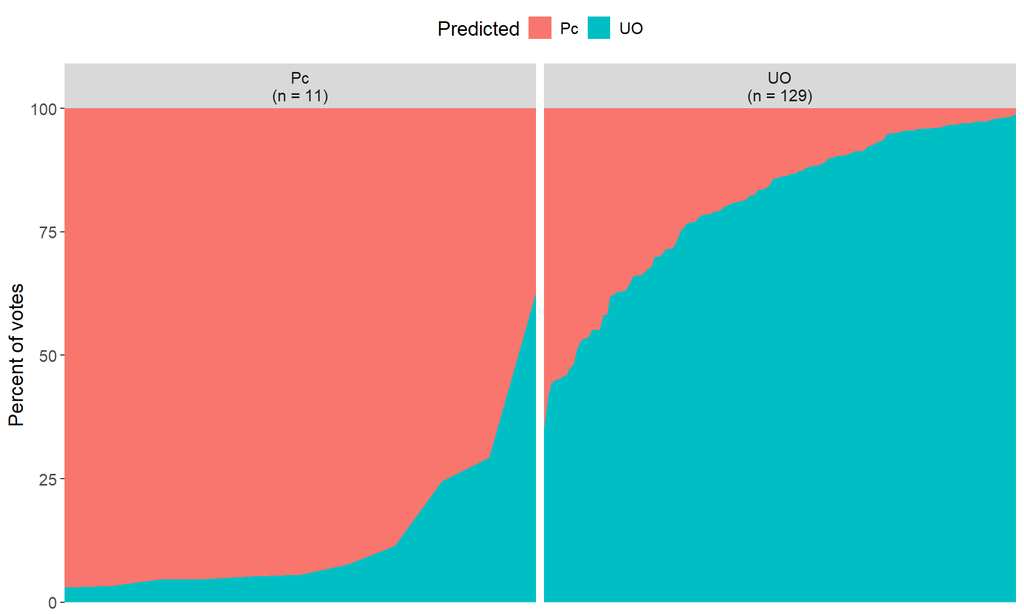

```r
# Plot Vote distribution
plotVotes(bant.rf_gl)
```

**Percent Correct**  
Another way to visualize this distribution is to evaluate the percent of events correctly classified for a given threshold (specified percent of trees in the forest voting for that species).

```r
# Percent Correct for a series of thresholds
pctCorrect(bant.rf_gl, pct = c(0.8, 0.6, 0.5))
```

```
    class pct.correct_0.8 pct.correct_0.6 pct.correct_0.5
1      Pc        72.72727        90.90909        90.90909
2      UO        62.01550        86.04651        93.02326
3 Overall        62.85714        86.42857        92.85714
```

**Plot Predicted Probabilities**  
The full distribution of assignment probabilities to the predicted species class can be visualized with the `plotPredictedProbs()` function in `rfPermute`. Ideally, all events would be classified to the correct species (identified by the color), and would be strongly classified to the correct species (higher probablity of assignment). This plot can be used to understand the distribution of these classifications, and how strong the misclassifications were, by species.

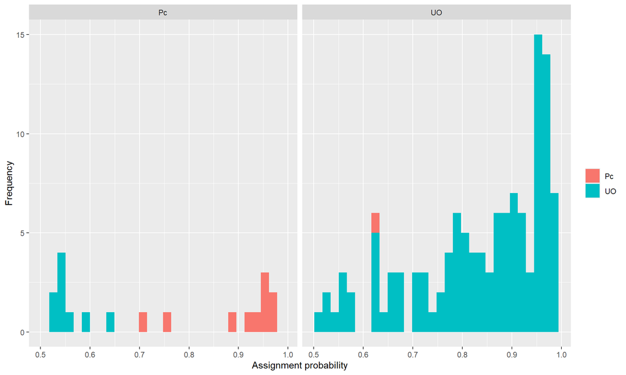

```r
plotPredictedProbs(bant.rf_gl, bins = 30, plot = TRUE)
```

**Proximity Plot**  
The proximity plot provides a visualization of the distribution of events within the tree space. It shows the relative distance of events based on their average distance in nodes in the trees across the forest. For each event in the plot, the color of the central dot represents the true species identity, and the color of the circle represents the *BANTER* classification. Ideally, these would form rather distinct clusters, one for each species. The wider the spread of the events in this feature space, the more variation found in these predictors. Some species differentiation may be predicted by other predictors and may not be clear based on this pair of dimensions (those may be differentiated with different predictors).

[figure not shown]

```r
# Proximity Plot
plotProximity(bant.rf_ll)
```

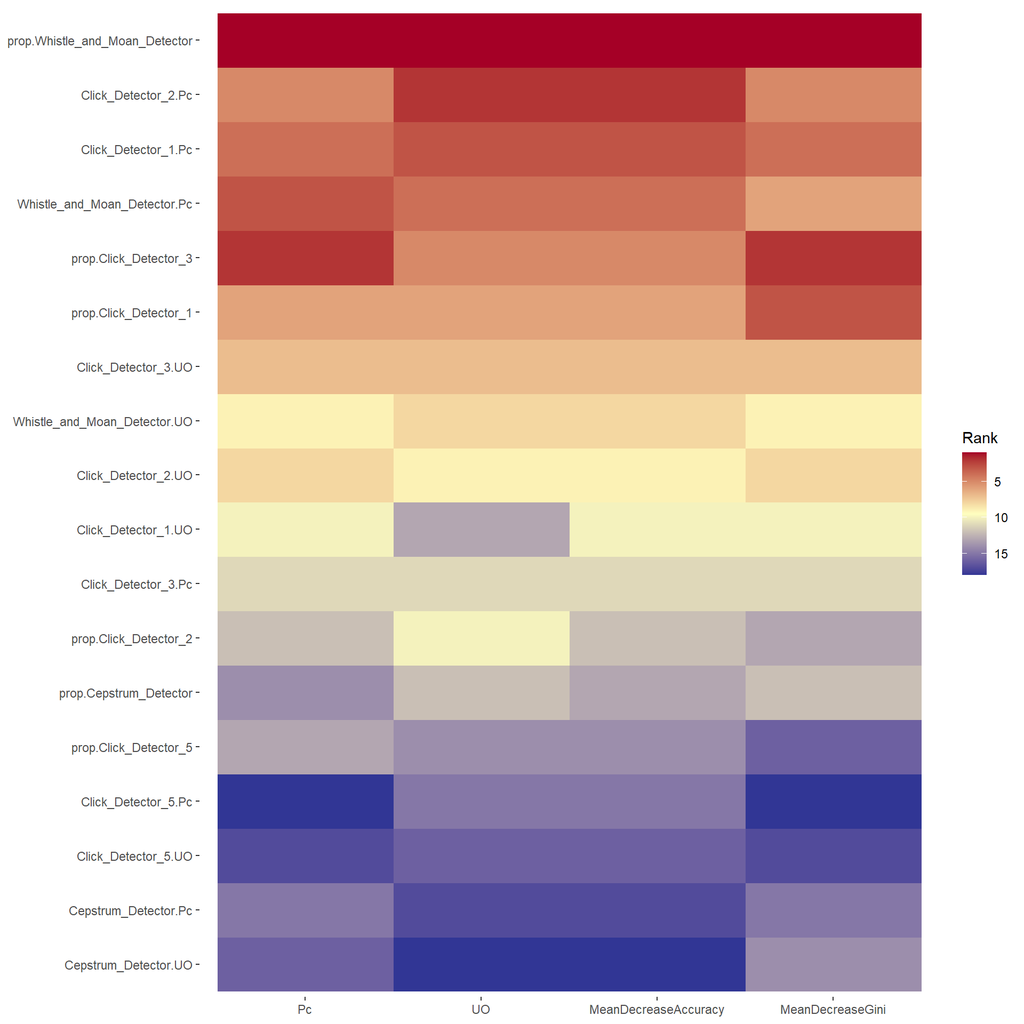

```r
# Importance Heat Map
plotImportance(bant.rf_gl, plot.type = "heatmap")
```

#### Mis-Classified Events

By segregating the misclassified events, you can dive deeper into these data to understand why the model failed. Perhaps they were incorrectly classified in the first place (inaccurate training data) or the misclassification could be due to natural variability in the call characteristics. There are any number of possibilities, and by diving into the misclassifications, you can learn a lot about your data and your model. We do not recommend eliminating misclassifications simply because they are misclassifications. The point is to learn more about your data, not to cherry pick your data to get the best performing model.

**Case Predictions** If it is important to identify only strong classification results, they can be identified and filtered using the `casePredictions()` function in `rfPermute`.

```r
casePredict <- casePredictions(bant.rf_gl)
head(casePredict)
```

```
                          id original predicted is.correct        Pc        UO
1 sg639_MHI_Apr2022.sg639_03       Pc        UO      FALSE 0.3713343 0.6286657
2 sg639_MHI_Apr2022.sg639_04       UO        UO       TRUE 0.1130308 0.8869692
3 sg639_MHI_Apr2022.sg639_05       UO        UO       TRUE 0.4175927 0.5824073
4 sg639_MHI_Apr2022.sg639_06       UO        UO       TRUE 0.3387955 0.6612045
5 sg639_MHI_Apr2022.sg639_07       Pc        Pc       TRUE 0.7068615 0.2931385
6 sg639_MHI_Apr2022.sg639_09       UO        UO       TRUE 0.2849418 0.7150582
```

This function returns a data frame with the original and predicted species for each event along with if the event was correctly classified and the assignment probabilities to each species.  
To identify misclassified events, we just filter this data frame and grab the original event id.

```r
misclass <- casePredict %>%
  filter(!is.correct) %>%
  select(id)

casePredict[casePredict$id %in% misclass$id,]
```

```
                             id original predicted is.correct        Pc
1    sg639_MHI_Apr2022.sg639_03       Pc        UO      FALSE 0.3713343
11   sg639_MHI_Apr2022.sg639_17       UO        Pc      FALSE 0.5431043
13   sg639_MHI_Apr2022.sg639_24       UO        Pc      FALSE 0.6482328
60   sg639_MHI_Apr2023.sg639_25       UO        Pc      FALSE 0.5484407
64   sg639_MHI_Apr2023.sg639_29       UO        Pc      FALSE 0.5858723
65   sg639_MHI_Apr2023.sg639_30       UO        Pc      FALSE 0.5554282
84   sg639_MHI_Apr2023.sg639_63       UO        Pc      FALSE 0.5249194
107  sg639_MHI_Apr2023.sg639_94       UO        Pc      FALSE 0.5502029
122 sg639_MHI_Apr2023.sg639_116       UO        Pc      FALSE 0.5192767
138 sg639_MHI_Apr2023.sg639_139       UO        Pc      FALSE 0.5409563
           UO
1   0.6286657
11  0.4568957
13  0.3517672
60  0.4515593
64  0.4141277
65  0.4445718
84  0.4750806
107 0.4497971
122 0.4807233
138 0.4590437
```

We can then look closer at these events to learn more about them.

#### Variable Importance

One of the powerful features of Random Forest is the ability to assess and rank which predictors are important to the classification model. These values are based on measures of how much worse the classifier performs when the predictor variables are randomly permuted. The `importance()` function in the `randomForest` package extracts these values from a `randomForest` object.

To see the actual distribution of these values in each species, we can first identify the most important predictors (highest importance scores).

```r
# Get importance scores and convert to a data frame
bant.imp <- data.frame(importance(bant.rf_gl))
head(bant.imp)
```

```
                                      Pc        UO MeanDecreaseAccuracy
prop.Cepstrum_Detector          4.666802  6.885120             7.523397
prop.Click_Detector_1          34.375770 19.883278            30.154103
prop.Click_Detector_2           8.656663 10.052480            10.948976
prop.Click_Detector_3          37.546475 23.199044            32.823261
prop.Click_Detector_5           5.053566  2.147813             3.514397
prop.Whistle_and_Moan_Detector 44.750845 39.191150            44.294622
                               MeanDecreaseGini
prop.Cepstrum_Detector               0.09304048
prop.Click_Detector_1                0.52319667
prop.Click_Detector_2                0.07935548
prop.Click_Detector_3                0.55852238
prop.Click_Detector_5                0.03164857
prop.Whistle_and_Moan_Detector       0.75487421
```

```r
# Select top 4 important event stage predictors
bant.4imp <- bant.imp[order(bant.imp$MeanDecreaseAccuracy, decreasing = TRUE), ][1:4, ]
bant.4imp
```

```
                                     Pc       UO MeanDecreaseAccuracy
prop.Whistle_and_Moan_Detector 44.75084 39.19115             44.29462
Click_Detector_2.Pc            34.78829 27.18463             34.00784
Click_Detector_1.Pc            35.08020 25.54637             33.28974
Whistle_and_Moan_Detector.Pc   35.47721 24.30387             32.94816
                               MeanDecreaseGini
prop.Whistle_and_Moan_Detector        0.7548742
Click_Detector_2.Pc                   0.5111838
Click_Detector_1.Pc                   0.5210131
Whistle_and_Moan_Detector.Pc          0.5091252
```

```r
# plotImpPreds(bant.rf_ll, bantData.df_ll, "species", max.vars = 4)
```

### Predictions

```r
# have to change the species names
uSp <- unique(banterDetsTrain_gl$events$species)
uSp <- uSp[-which(uSp == 'UO' | uSp == 'Pc')]

for (u in seq_along(uSp)){
  uSpIdx <- which(banterDetsTrain_gl$events$species == uSp[u])
  banterDetsTrain_gl$events$species[uSpIdx] <- 'UO'
}

# unique(banterDetsTrain$events$species)

# Check for click_detector_0 in training dataset
banterDetsTrain_gl$detectors$Click_Detector_0 <- NULL

# predict on glider data with glidermodel
score_gl_gl <- banter::predict(bant.mdl_gl, banterDetsTrain_gl)
save(score_gl_gl, file = file.path(path_models, 'predictions_GLbyGL.rda'))

score_gl_gl$validation.matrix
```

```
        predicted
original  Pc  UO
      Pc  11   0
      UO   8 121
```

```r
# predict on glider data with towed array
score_gl_ta <- banter::predict(bant.mdl_ta, banterDetsTrain_gl)
save(score_gl_ta, file = file.path(path_models, 'predictions_GLbyTA.rda'))

score_gl_ta$validation.matrix
```

```
        predicted
original X33 X577
      Pc  10    1
      UO   0  129
```

```r
# predict on glider data with longline
score_gl_ll <- banter::predict(bant.mdl_ll, banterDetsTrain_gl)
save(score_gl_ll, file = file.path(path_models, 'predictions_GLbyLL.rda'))

score_gl_ll$validation.matrix
```

```
        predicted
original  Pc  UO
      Pc  10   1
      UO   6 123
```